# oregon_health2

John Morse

4/16/2020

**1 Question:** The main outcome, or dependent variable, of interest will be “ed_visits”, which is the self-reported number of Emergency Department visits during the previous 12 months. You can use the “summarize” command, along with the “detail” option, to display summary statistics for a variable. Report each of the following statistics for “ed_visits”: mean, standard deviation, median, 90th percentile, 99th percentile.

*Answer:*

Mean: **0.99**

Standard Deviation: **1.96**

Median: **0**

90th Percentile: **3**

99th Percentile: **10**

**2 Question:** The main regressor, or independent variable, of interest will be “medicaid”, which is an indicator for whether a person was enrolled in Medicaid at the time of the survey. Note that this Medicaid enrollment indicator is not randomized. For “medicaid”, report the mean and standard deviation.

*Answer:*

Mean: **0.29**

Standard Deviation: **0.45**

**3 Question:** The “regress” command can be used to estimate a linear regression (OLS). Robust standard errors allow for the possibility of heteroskedasticity, which is when the variance of the dependent variable may differ across values of the independent variables. In each of the following linear regressions, use the “, robust” option in order to incorporate robust standard errors. Thus, the basic syntax for these commands is “regress ed_visits medicaid, robust”. Estimate a linear regression where “ed_visits” is the dependent variable, “medicaid” is the independent variable, and there are no other covariates. What is your estimated coefficient on “medicaid”? Is it statistically significant at the 5% level? How do you interpret your estimated coefficient?

*Answer*

Method One: The estimated coefficient on medicaid is **0.48100**. The p-value is very low at **<2e-16**; this means that this is statstically significant. I interpret my estimated coefficient as referring to the relationship between my two variables of interest; specifically it is the slope of medicaid is .48100. In other words, with every one increase of medicaid, there should be an associated increase of, on average, .48100 units of ed visits.

**4 Question:** Estimate a linear regression as in the previous question, but include the following covariates as well: “female”, “age_35_49_inp”, “age_50_64_inp”. We’ll refer to these variables as “gender-age controls” later in the assignment. What is your estimated coefficient on “medicaid”? Is it smaller or larger compared to what you obtained in the previous question?

*Answer* My estimated coefficient on “medicaid” is **.45787**. This is a **smaller** coefficient than what I obtained in the previous question.

**5 Question:** Estimate a linear regression as in the previous question, but now add the following covariates as well: “ast_dx_pre_lottery”, “dia_dx_pre_lottery”, “hbp_dx_pre_lottery”, “chl_dx_pre_lottery”, “ami_dx_pre_lottery”, “chf_dx_pre_lottery”, “emp_dx_pre_lottery”, “kid_dx_pre_lottery”, “cancer_dx_pre_lottery”, “dep_dx_pre_lottery”. We’ll refer to these variables as “diagnosis controls” later in the assignment. Note that these variables are indicators for various health diagnoses prior to Medicaid enrollment. What is your estimated coefficient on “medicaid”? How does this compare to what you obtained in your original linear regression from question 3, when there were no additional covariates? Why might there be a change in the “medicaid” coefficient when you include additional covariates?

*Answer:*

**Not sure if this right. Are we supposed to get rid of the gender-age controls?** My estimated coefficient on medicaid is: **0.41378**. This value is smaller than my original coefficient. There might be a change on the medicaid coefficient as I include additional covariates because in the first equation I am ignoring the covariates whereas in this equation I am *controlling* for them. When we control for covariates our estimate differs as we are holding these covariates constant which should increase the accuracy of our model.

```r
# Here I have called every variable individually rather than doing it by calling the individual variables.

na_removed <- data %>%
  filter(ed_visits != NA)

logit_model1 <- glm(medicaid ~ female + age_35_49_inp + age_50_64_inp + ast_dx_pre_lottery + dia_dx_pre_lottery + hbp_dx_pre_lottery + chl_dx_pre_lottery + ami_dx_pre_lottery + chf_dx_pre_lottery + emp_dx_pre_lottery + kid_dx_pre_lottery + cancer_dx_pre_lottery + dep_dx_pre_lottery, family = binomial, data = data)
```

```r
# Here I run the prediction on the model I created in question 6

mylogit <- predict(logit_model1, newdata = data, type = "response")

# No I am saving this table so that I can pull my desired values (mean and standard deviation)

test <- summary(mylogit)
test
```

```
##    Min. 1st Qu.  Median    Mean 3rd Qu.    Max.    NA's
##  0.2094  0.2379  0.3049  0.2908  0.3234  0.6150       1
```

```r
mean <- test[[4]]
sd <- sd(test)
```

**7.Question:** Using the “predict” command immediately following the “logit” command allows one to generate a variable with the predicted values implied by the estimates from the “logit” command. Use the “predict” command to generate “medicaid_hat”, the predicted probabilities of Medicaid enrollment based on the covariates used in the logistic regression. What is the mean and standard deviation of “medicaid_hat”?

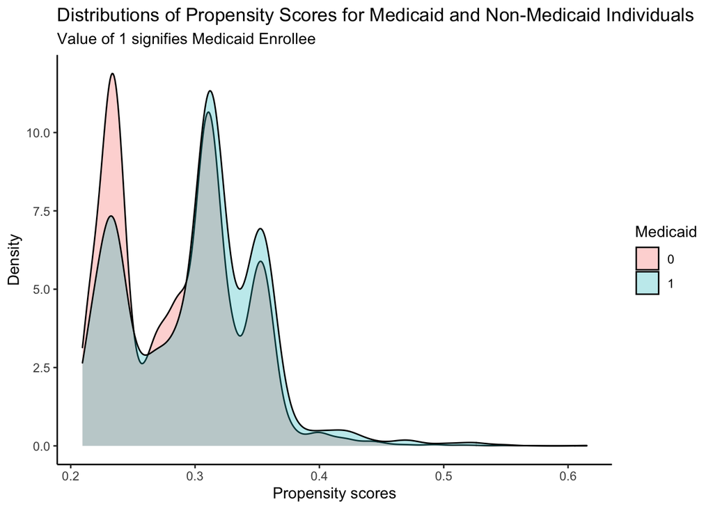

```r
# Here I have created a density plot


ggplot(data, aes(x = mylogit, fill = as.factor(medicaid))) +
  geom_density(alpha = 0.3) +
  labs(title = "Distributions of Propensity Scores for Medicaid and Non-Medicaid Individuals",
       subtitle = "Value of 1 signifies Medicaid Enrollee",
       x = "Propensity scores",
       y = "Density",
       fill = "Medicaid") +
  theme_classic()
```

**8.Question:** Note that “medicaid_hat” is in fact a propensity score. Examine the “common support” assumption underlying PSM by plotting the distributions of propensity scores for Medicaid participants and nonparticipants.

```
Include your density plot in your write-up. What is the range of propensity scores for nonparticipants? What is the range of propensity scores for participants? Does the “common support” assumption appear to be valid?
```

*Answer:*

The range of propensity scores appears to be *0.2 to just over 0.6*. The common support assumption does appear to be valid as the distribution of density appears to be relatively similar for both groups with deviation minimized.

**9.Question:** The command “teffects psmatch” can be used, with the “, atet” option, to estimate a TOT effect using PSM. Note that by default the command will estimate an ATE, which is slightly different, so be sure to specify the “, atet” option to obtain TOT estimates. Use this command to obtain an estimate of the effect of Medicaid enrollment on ED visits, using the same covariates that were used to generate propensity scores (“gender-age controls” and “diagnosis controls”). Use nearest-neighbor matching with 1 match. Note this will require using the Stata help file for the appropriate syntax. What is your PSM estimate of the TOT effect? Is it statistically significant at the 5% level?

```r
library(MatchIt)

# Here I had to remove the na values in order to run my match it function below

x <- data %>%
  na.omit(TRUE)

neighbor <- matchit(medicaid ~ female + age_35_49_inp + age_50_64_inp + ast_dx_pre_lottery + dia_dx_pre_lottery + hbp_dx_pre_lottery + chl_dx_pre_lottery + ami_dx_pre_lottery + chf_dx_pre_lottery + emp_dx_pre_lottery + kid_dx_pre_lottery + cancer_dx_pre_lottery + dep_dx_pre_lottery, family = binomial, data = x, method = "nearest", ratio = 1)
neighbor
```

```
##
## Call:
## matchit(formula = medicaid ~ female + age_35_49_inp + age_50_64_inp +
##     ast_dx_pre_lottery + dia_dx_pre_lottery + hbp_dx_pre_lottery +
##     chl_dx_pre_lottery + ami_dx_pre_lottery + chf_dx_pre_lottery +
##     emp_dx_pre_lottery + kid_dx_pre_lottery + cancer_dx_pre_lottery +
##     dep_dx_pre_lottery, data = x, method = "nearest", family = binomial,
##     ratio = 1)
##
## Sample sizes:
##           Control Treated
## All          8640    3534
## Matched      3534    3534
## Unmatched    5106       0
## Discarded       0       0
```

```r
summary <- summary(neighbor)
summary
```

```
##
## Call:
## matchit(formula = medicaid ~ female + age_35_49_inp + age_50_64_inp +
##     ast_dx_pre_lottery + dia_dx_pre_lottery + hbp_dx_pre_lottery +
##     chl_dx_pre_lottery + ami_dx_pre_lottery + chf_dx_pre_lottery +
##     emp_dx_pre_lottery + kid_dx_pre_lottery + cancer_dx_pre_lottery +
##     dep_dx_pre_lottery, data = x, method = "nearest", family = binomial,
##     ratio = 1)
##
## Summary of balance for all data:
##                       Means Treated Means Control SD Control Mean Diff eQQ Med
## distance                     0.2994        0.2866     0.0501    0.0129  0.0101
## female                       0.6358        0.5369     0.4987    0.0989  0.0000
## age_35_49_inp                0.3693        0.3716     0.4833   -0.0024  0.0000
## age_50_64_inp                0.2702        0.2787     0.4484   -0.0085  0.0000
## ast_dx_pre_lottery           0.2068        0.1875     0.3903    0.0193  0.0000
## dia_dx_pre_lottery           0.0722        0.0704     0.2558    0.0018  0.0000
## hbp_dx_pre_lottery           0.1836        0.1806     0.3847    0.0031  0.0000
## chl_dx_pre_lottery           0.1319        0.1243     0.3299    0.0076  0.0000
## ami_dx_pre_lottery           0.0266        0.0167     0.1280    0.0099  0.0000
## chf_dx_pre_lottery           0.0150        0.0094     0.0964    0.0056  0.0000
## emp_dx_pre_lottery           0.0286        0.0196     0.1385    0.0090  0.0000
## kid_dx_pre_lottery           0.0221        0.0168     0.1285    0.0053  0.0000
## cancer_dx_pre_lottery        0.0492        0.0400     0.1961    0.0092  0.0000
## dep_dx_pre_lottery           0.3834        0.3226     0.4675    0.0608  0.0000
##                       eQQ Mean eQQ Max
## distance                0.0129  0.0748
## female                  0.0990  1.0000
## age_35_49_inp           0.0023  1.0000
## age_50_64_inp           0.0085  1.0000
## ast_dx_pre_lottery      0.0192  1.0000
## dia_dx_pre_lottery      0.0017  1.0000
## hbp_dx_pre_lottery      0.0031  1.0000
## chl_dx_pre_lottery      0.0076  1.0000
## ami_dx_pre_lottery      0.0099  1.0000
## chf_dx_pre_lottery      0.0057  1.0000
## emp_dx_pre_lottery      0.0091  1.0000
## kid_dx_pre_lottery      0.0054  1.0000
## cancer_dx_pre_lottery   0.0091  1.0000
## dep_dx_pre_lottery      0.0608  1.0000
```

[output cut: 42 more lines]

```
## hbp_dx_pre_lottery       26.7176       0   27.2727  0.0000
## chl_dx_pre_lottery      -19.8315       0  -18.5185  0.0000
## ami_dx_pre_lottery       85.7550       0   85.7143  0.0000
## chf_dx_pre_lottery       64.7688       0   65.0000  0.0000
## emp_dx_pre_lottery       90.5880       0   90.6250  0.0000
## kid_dx_pre_lottery        3.6968       0    5.2632  0.0000
## cancer_dx_pre_lottery    81.5250       0   81.2500  0.0000
## dep_dx_pre_lottery       99.0699       0   99.0698  0.0000
##
## Sample sizes:
##           Control Treated
## All          8640    3534
## Matched      3534    3534
## Unmatched    5106       0
## Discarded       0       0
```